# Estimating Subnational Micronutrient Deficiency Prevalence

A SuperLearner Ensemble Approach — Multi-Country Analysis

Andrew N. Mertens, UC Davis Institute for Global Nutrition

2025-12-31

# Motivation

## The Biomarker Data Gap

- Micronutrient deficiency (iron, vitamin A, zinc, folate, B12) drives child and maternal morbidity across sub-Saharan Africa
- Nationally representative **biochemical surveys are rare** — conducted at decadal intervals
- Between survey cycles, **sub-national burden is essentially unknown**
- Program allocation relies on outdated or modelled estimates

**Can we estimate micronutrient deficiency from routinely available proxy data?**

**Current focus micronutrients:**

- Iron deficiency (ferritin)
- Vitamin A deficiency (RBP)
- Zinc deficiency
- Folate deficiency
- Vitamin B12 deficiency

**Countries:** Gambia, Ghana, Sierra Leone, Malawi + Cote d’Ivoire (OOS)

## Objective

**Primary objective:** Estimate Admin-1 and national prevalence of micronutrient deficiencies across four countries using a SuperLearner ensemble with multi-source proxy predictors — external data available without a concurrent biomarker survey.

**Secondary objectives:**

1. Quantify prediction uncertainty via split-conformal prediction intervals
2. Assess predictor domain contributions via permutation-based domain ablation
3. Evaluate cross-country transportability via leave-one-country-out (LOCO) validation
4. Generate out-of-sample predictions for Cote d’Ivoire with covariate-shift adjusted CIs
5. Identify key individual predictors via variable importance analysis

# Data Architecture

## Predictor Strategy: 13+ Proxy Data Sources

**Proxy-only models** — survey-derived (`gw_`) variables excluded to prevent data leakage.

| Domain | Source | Approx. N cols |
| --- | --- | --- |
| DHS cluster aggregates | DHS API | ~400 |
| MICS indicators | MICS compilations | ~150 |
| IHME disease estimates | GBD geospatial | ~60 |
| MAP malaria surfaces | Malaria Atlas Project | ~26 |
| WFP food prices | WFP VAM | ~46 |
| GEE satellite imagery | Google Earth Engine Admin-2 zonal means | ~308 |
| CHIRPS rainfall | UCSB CHIRPS | ~12 |
| WorldPop density | WorldPop | ~5 |
| VIIRS nighttime lights | NOAA/CCNL | ~3 |
| SoilGrids | ISRIC | ~15 |
| GDL development indices | Global Data Lab | ~5 |
| HarvestChoice/SPAM crops | IFPRI | ~20 |
| **Total proxy** |  | **~900–1,100** |

## Outcome and Population Structure

**Four core outcomes** (fitted independently per country):

| Population | Micronutrient | Binary threshold | Countries |
| --- | --- | --- | --- |
| Children | Vitamin A | RBP < 0.70 umol/L | All 4 |
| Women | Vitamin A | RBP < 0.70 umol/L | All 4 |
| Children | Iron | Ferritin < 12 ug/L | All 4 |
| Women | Iron | Ferritin < 15 ug/L | All 4 |
| Women | Folate | Serum folate < 10 nmol/L | GH, SL, MW |
| Women | Vitamin B12 | Serum B12 < 148 pmol/L | GH, SL, MW |
| Children/Women | Zinc | Serum zinc < threshold | MW only |

**24 country x outcome models** fitted in the full pipeline.

# Modeling Strategy

## SuperLearner Ensemble (Full Stack)

| Class | Learners | Notes |
| --- | --- | --- |
| Regularized linear | Lasso, Ridge, Elastic net | L1/L2/mixed penalty |
| Random forest | Ranger x3 | Varying depth and mtry |
| Gradient boosting | XGBoost x2 | Conservative + deep |
| Bayesian trees | BART x3 | 50/100/200 trees |
| Other | Gaussian process | Smooth spatial patterns |

**Additional for rare outcomes (prevalence < 15%):**

- Class-weighted XGBoost (minority upweighting)
- Class-weighted Ranger

**Cross-validation:** 5-fold, cluster-blocked (no cluster in both train and validation)

## Uncertainty: Split-Conformal Prediction Intervals

| Step | Action |
| --- | --- |
| 1 | Split data into training + calibration sets (cluster-blocked) |
| 2 | Fit full SL on training set |
| 3 | Compute nonconformity scores on calibration set |
| 4 | Construct adaptive-width intervals using calibration quantiles |
| 5 | Aggregate to Admin-1/national with intervals |

**For out-of-sample (CIV):** Weighted conformal with covariate-shift density ratios

# Results: Within-Country Performance

## Binary Model AUC Across Countries

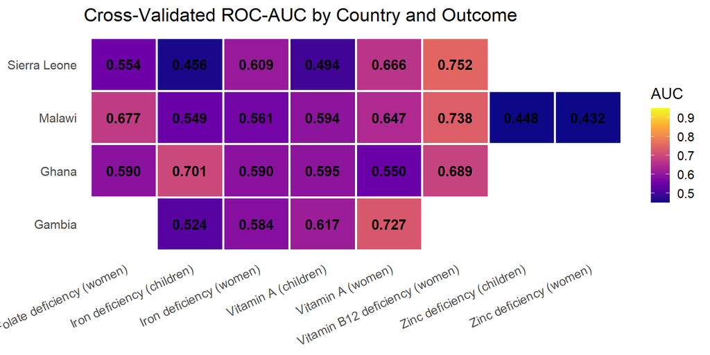

## AUC Forest Plot with DeLong CIs

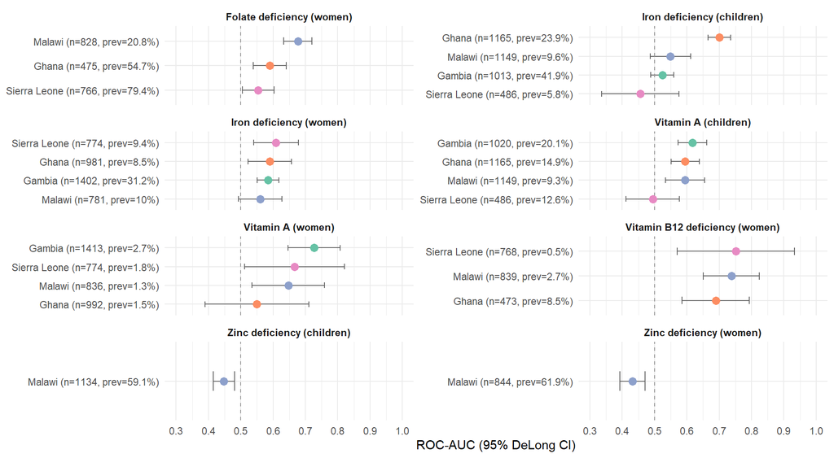

## Key Performance Findings

**Rebuilt 2026-08** (full mode, 12-learner stack, 4 countries, 831 targets, 0 errors). A fifth country, Tanzania, was added and then withdrawn (see Full Rebuild slide); the numbers below reflect the four-country pipeline.

**Across all 24 binary country x outcome cells**

**Highest AUCs (all rare outcomes)**

[output not shown]

**Performance is highest where events are fewest**

$r$(AUC, log events) = **-0.521** (95% CI -0.764 to -0.149, $p$ = 0.009, n = 24)

| Event tertile | median events | median AUC |
| --- | --- | --- |
| Few | 19 | 0.741 |
| Middle | 93 | 0.592 |
| Many | 431 | **0.562** |

**Read the many-events tertile as the honest estimate of discrimination.**

## Evaluating Models for Rare Outcomes

| Dimension | Metric | What it tells you |
| --- | --- | --- |
| **Discrimination** | ROC-AUC, **PR-AUC** | Can the model rank individuals by risk? |
| **Calibration** | Cal. slope, Cal. intercept | Are predicted probabilities accurate? |
| **Prevalence recovery** | Predicted vs. observed | Does the model get the right burden? |

For **subnational mapping**, prevalence recovery matters more than individual-level discrimination. A model with AUC = 0.65 can still accurately estimate Admin-1 prevalence if well calibrated.

# Domain Importance

## Cross-Outcome Domain Importance

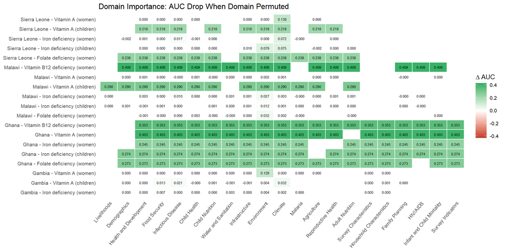

## Domain Importance: Key Findings

**Policy implication:** Maintaining diverse data inputs across multiple thematic areas is more important than investing heavily in any single data source.

## Individual Variable Importance (Top-2 Models)

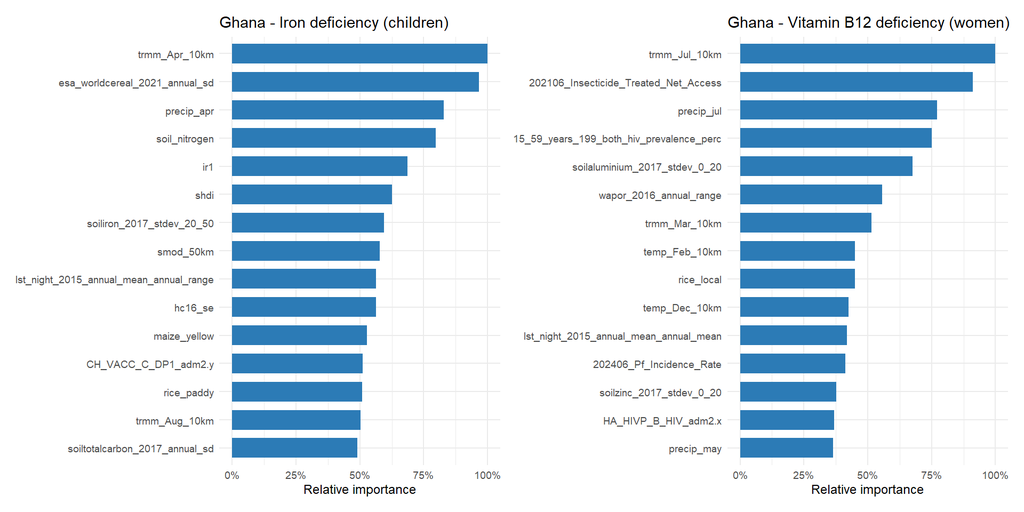

*Ranger impurity-based importance from 1000-tree RF on same preprocessed data*

## Variable Importance: Key Patterns

**Ghana child iron** (AUC = 0.702, rebuilt 2026-08):

- Rainfall (TRMM April, CHIRPS April) — seasonal precipitation patterns
- Land cover (ESA WorldCereal) — agricultural land use
- Soil nitrogen, soil iron — geochemical correlates
- MICS indicators, GDL subnational HDI

- Rainfall (TRMM July, CHIRPS July) — wet season patterns
- MAP insecticide-treated net access
- IHME HIV prevalence — disease burden correlate
- WFP rice prices — food access indicator

**Common theme:** Climate/rainfall and environmental variables dominate, suggesting strong agro-ecological gradients drive micronutrient status.

# Transportability

## Leave-One-Country-Out (LOCO) Cross-Validation

**Design:** Train on 3 countries, predict on held-out 4th. Repeat for all 4.

LOCO transportability results

|  | held_out | n_train | n_test | prev_test | pred_prev | auc | brier | null_brier | null_brier_train | calib_intercept | calib_slope | calib_scale | outcome |
| --- | --- | --- | --- | --- | --- | --- | --- | --- | --- | --- | --- | --- | --- |
| (Intercept)...1 | Gambia | 2800 | 1020 | 0.201 | 0.190 | 0.575 | 0.159 | 0.161 | 0.167 | -0.304 | 0.733 | logit | child_vitA |
| (Intercept)...2 | Ghana | 2655 | 1165 | 0.149 | 0.126 | 0.595 | 0.126 | 0.127 | 0.127 | 0.043 | 0.916 | logit | child_vitA |
| (Intercept)...3 | SierraLeone | 3334 | 486 | 0.126 | 0.137 | 0.538 | 0.111 | 0.110 | 0.110 | -3.568 | -0.875 | logit | child_vitA |
| (Intercept)...4 | Malawi | 2671 | 1149 | 0.093 | 0.107 | 0.545 | 0.085 | 0.084 | 0.090 | -0.748 | 0.718 | logit | child_vitA |
| (Intercept)...5 | Gambia | 2602 | 1413 | 0.027 | 0.012 | 0.735 | 0.026 | 0.026 | 0.026 | 5.089 | 1.983 | logit | women_vitA |
| (Intercept)...6 | Ghana | 3023 | 992 | 0.015 | 0.011 | 0.640 | 0.015 | 0.015 | 0.015 | 0.573 | 1.064 | logit | women_vitA |
| (Intercept)...7 | SierraLeone | 3241 | 774 | 0.018 | 0.013 | 0.576 | 0.018 | 0.018 | 0.018 | -9.818 | -1.319 | logit | women_vitA |
| (Intercept)...8 | Malawi | 3179 | 836 | 0.013 | 0.022 | 0.581 | 0.013 | 0.013 | 0.013 | -0.415 | 1.034 | logit | women_vitA |
| (Intercept)...9 | Gambia | 2800 | 1013 | 0.420 | 0.295 | 0.581 | 0.255 | 0.244 | 0.317 | 0.221 | 0.602 | logit | child_iron |
| (Intercept)...10 | Ghana | 2648 | 1165 | 0.239 | 0.873 | 0.635 | 0.584 | 0.182 | 0.182 | -1.807 | 0.207 | logit | child_iron |
| (Intercept)...11 | SierraLeone | 3327 | 486 | 0.058 | 0.072 | 0.508 | 0.055 | 0.054 | 0.089 | -2.121 | 0.255 | logit | child_iron |
| (Intercept)...12 | Malawi | 2664 | 1149 | 0.096 | 0.091 | 0.507 | 0.087 | 0.087 | 0.118 | -1.961 | 0.121 | logit | child_iron |
| (Intercept)...13 | Gambia | 2749 | 1402 | 0.312 | 0.176 | 0.609 | 0.225 | 0.215 | 0.265 | 0.708 | 0.953 | logit | women_iron |
| (Intercept)...14 | Ghana | 3065 | 1086 | 0.076 | 0.999 | 0.591 | 0.921 | 0.071 | 0.085 | -3.100 | 0.054 | logit | women_iron |
| (Intercept)...15 | SierraLeone | 3324 | 827 | 0.088 | 0.041 | 0.542 | 0.084 | 0.080 | 0.089 | -2.504 | -0.049 | logit | women_iron |
| (Intercept)...16 | Malawi | 3315 | 836 | 0.103 | 0.099 | 0.507 | 0.093 | 0.092 | 0.098 | -2.724 | -0.252 | logit | women_iron |

## Admin-2 estimation: fit at the unit of deliverable

**Within-country area-level SuperLearner (fit directly on admin-2 aggregates) dramatically outperforms aggregating an individual-level SL to admin-2:**

| Approach | Pearson r (admin-2, median across 30 country–outcomes) | MAE (pp) | Bias |
| --- | --- | --- | --- |
| Individual SL → aggregate to admin-2 | 0.55 (range −0.39 to 0.87) | 4–21 | Often large negative |
| **Area SL (MSE)** — fit at admin-2 | **0.97** (r > 0.9 in 27 of 30) | **1–11** | Near zero |
| Area SL (NLL) | 0.94 | 1–14 | Near zero |

Aggregating individual-level predictions to admin-2 introduces characteristic *shrinkage compression*: high-prevalence districts are systematically under-predicted (e.g., Gambia child-iron MAE 20.8 pp, bias −20.4 pp).

> This is the classic small-area-estimation lesson [Mercer 2015, Wakefield 2019]: **fit at the unit of deliverable**. If the output is an admin-2 map, fit at admin-2; if the output is household-level risk, fit at the individual level.

## Cross-country (LOCO) admin-2 transportability is limited

LOCO Pearson r between predicted and observed admin-2 prevalence:

| Outcome | Held-out best | Held-out worst | Median |
| --- | --- | --- | --- |
| child_iron | Ghana (r=0.53) | Malawi (r=−0.02) | 0.31 |
| women_iron | Gambia (r=0.40) | Sierra Leone (r=−0.08) | 0.15 |
| child_vitA | Ghana (r=0.38) | Malawi (r=0.18) | 0.27 |
| women_vitA | Ghana (r=0.17) | Sierra Leone (r=−0.15) | 0.03 |

## Benchmark comparison: does the SuperLearner beat simpler methods?

We compared the area-level SL against four canonical baselines:

| Method | Why include |
| --- | --- |
| Country-mean baseline | Is the model doing anything? |
| OLS (top-8 covariates) | Is anything more than linear needed? |
| Penalised GLM (elastic-net) | Best frequentist comparator |
| Fay–Herriot (`sae`) | Industry standard SAE |
| BYM2 (INLA, PC priors) | Bayesian areal disease-mapping |

**Preliminary head-to-head, 16 LOCO splits:**

> **SuperLearner wins:** 7 **Benchmark wins:** 9

The 17.7-h SL pipeline does **not consistently beat** an 8-variable OLS or penalised regression. Where SL wins, it does so via genuine non-linearity (ranger consistently the winning learner).

**Stark example:** child-iron Sierra Leone — SL r = **−0.19** (anti-predictive), plain OLS r = **0.37**. Ensemble model selection failed; a simpler regularised model recovered the signal.

# Out-of-Sample: Cote d’Ivoire

## CIV Predictions

**Approach:** Pooled elastic net trained on all 4 countries applied to CIV Admin-2 polygons using GEE satellite predictors only.

**Weighted conformal CIs** account for covariate shift between training countries and CIV.

|  | Outcome | Admin-1 units | Mean prev (%) | Range (%) |
| --- | --- | --- | --- | --- |
| child_vitA | Vitamin A (children) | 14 | 12.4 | 9.8--16.5 |
| women_vitA | Vitamin A (women) | 14 | 1.5 | 1.1--1.9 |
| child_iron | Iron deficiency (children) | 14 | 21.3 | 12.2--32.2 |
| women_iron | Iron deficiency (women) | 14 | 14.5 | 6.4--22.1 |

# Discussion

## Milestones

| Deliverable | Status |
| --- | --- |
| Scientific Advisory Board | Established |
| Multi-country pipeline (4 countries) | Complete |
| Full learner stack (12 learners incl. 3 BART sizes) | Complete |
| Conformal prediction intervals | Complete |
| 13+ external predictor sources | Complete |
| LOCO transportability (4 outcomes) | Complete |
| CIV out-of-sample predictions | Complete |
| Domain ablation (permutation-based) | Complete |
| Variable importance (top-2 models) | Complete |
| Folate, B12, zinc outcomes | Complete (where data available) |
| Sierra Leone mean-learner fix | Complete |
| Gridded pixel-level maps | Planned |
| Interactive dashboard (Shiny) | Planned |

## Next Steps

**Immediate:**

- Re-run the pipeline: the review fixes change model inputs
- Residualise the VMNIS outcome out-of-fold and re-score
- Prepare Phase 2 report to Gates Foundation

**Longer-term:**

- Gridded (pixel-level) prevalence maps
- Additional countries beyond current 4 + CIV
- Integrate into DInA prioritization framework
- Interactive Shiny dashboard with leaflet maps
- Harmonise survey weight scales across countries
- Expand the VMNIS national panel beyond vitamin A

# Methods Review 2026-08

## What the review changed

A systematic re-audit of the area-level and LOCO models (`sandbox_parsimony/FINDINGS.md`, 24 sections, 34 result tables) found **four data bugs, three inflated performance numbers, and one clear modelling win**. Several previously reported results do not survive; they are corrected here rather than quietly dropped.

**Data integrity**

- GADM **water bodies used as prediction units** — `Lake Malawi` (n=21–33) and `Lake Victoria` (n=60–110) appear in the *survey* tables. Respondents geocoded onto lakes.
- **Duplicate Admin-2 names** cause silent cartesian joins (inflated one table 256 → 29,183 rows).
- **Fay–Herriot ignored its own sampling variance** — single-PSU districts return SE ≈ 1e-17, which passed a `D <= 0` guard. The EBLUP kept ~71% of the raw direct estimate, not ~26%.
- **Survey weights sit on inconsistent scales** — Malawi median 790,000, Ghana 0.98. Harmless for weighted means, fatal anywhere weights act as precision.

## The outcome is noise-dominated, and nothing said so

A ceiling is now reported next to every correlation:

$$\lambda = 1 - \frac{E[V_\text{sampling}]}{\mathrm{Var}(p_\text{obs})}, \qquad r_{\max} = \sqrt{\lambda}$$

A median Admin-2 district contributes **6–36 biomarker measurements**.

| cell | published CV r | r_max | % of ceiling |
| --- | --- | --- | --- |
| Ghana child iron | 0.609 | 0.672 | **77–91%** — saturated |
| Gambia women iron | 0.538 | 0.706 | 68–76% |
| Malawi child iron | 0.038 | 0.199 | 7–19% — real headroom |
| Ghana / Malawi women vit A | −0.039 / 0.176 | **0.00** | nothing to predict |

Two very different situations were being presented identically. Cells whose ceiling is indistinguishable from zero are now blanked in the results tables, not reported as model failures.

## Three published numbers do not survive

| claim | published | honest | why |
| --- | --- | --- | --- |
| `spatial_plus_soil` leads LOCO | rho = 0.305 | **rho = 0.117** | its 8 soil features were ranked by LOCO r on the *same* outcomes and held-out countries |
| adaptive variable selection helps | — | no reliable gain | selecting once on all data inflates rho by **+0.30** (Admin-1), **+0.16** (Admin-2) |
| an Admin-1 layer would roughly double accuracy | proposed | **rejected** | ceiling doubles but achieved rho *halves* (0.064 vs 0.137) — 16–32 regions is too few to fit on |

Any variable-selection step must sit **inside** the resampling loop. Selection done first is the single largest source of optimism found in this review — larger than every genuine modelling difference combined.

## The clear win: parsimony plus geography

**16 a-priori variables + longitude/latitude in a random forest** beat the 237–487-predictor production recipe in **14 of 16** country × outcome cells (paired delta-Spearman **+0.063**, t = 4.9).

| model | rho | r / r_max |
| --- | --- | --- |
| **curated 16 + lon/lat, RF** | **0.374** | 0.58 |
| 20 cluster reps + lon/lat, RF | 0.362 | 0.60 |
| *spatial only, no covariates* | 0.347 | 0.53 |
| production (top-30 screen, enet) | 0.310 | 0.49 |
| ridge on all 237–487 | 0.230 | 0.32 |

**18 predictors, not 237.**

A covariate-free lon/lat smoother already out-scores the production recipe — geography must be **in** the model, not treated as an alternative to it.

Ridge on the full pool is the **worst** covariate model: pool redundancy is actively harmful when nothing selects against it.

## Level and pattern are different problems

LOCO transports the **spatial pattern** modestly and the **level** not at all.

- Best pattern transfer: train on the within-country z-score, rho 0.154 → **0.261**
- Level: the best LOCO model misses national prevalence by **5.4 pp** on average and by a factor of **2–3** on iron (Malawi child iron 10.6% actual → 28.4% predicted)

**Fix — national benchmarking, now default-on.** A logit-scale shift solved so the population-weighted aggregate equals the design-based national estimate:

|  | before | after |
| --- | --- | --- |
| national error | 4.33 pp | **0.00 pp** |
| district Spearman change | — | **0.0000** (strictly monotone) |

The survey’s *own* district estimates aggregate **4.50 pp** away from the national figure the same survey produces. Most of the model drift is inherited from the direct estimates, not created by the model — these surveys are powered for national, and Admin-2 is an unplanned domain.

## Absolute accuracy: honest framing

Against the comparator a programme already has — paint the national mean on every district:

|  | model | national-mean map |
| --- | --- | --- |
| WHO severity band correct | 60.2% | 53.6% |
| MAE | 13.9 pp | 15.4 pp |
| worst-20% districts recovered | 27.1% | 20% (random) |

A targeting lift of **1.36x**. The map beats doing nothing, but not by much. It is useful for *ranking* districts within the better-measured outcomes, and should not be quoted as a district prevalence estimate.

## A national model from national data (VMNIS)

The full WHO VMNIS dump holds **187 countries** (the project extract had 8). Vitamin A in preschool children: **528 surveys, 70 countries**.

Leave-one-**country**-out, World Bank covariates, no benchmarking:

| model | MAE | Pearson |
| --- | --- | --- |
| random forest | **11.6 pp** | 0.187 overall, 0.648 for vitamin A |
| global mean (null) | 13.1 pp | — |

**Read against the ceiling.** Repeat national surveys of the *same* country disagree by ~1.1 on the logit scale, so r_max = 0.66 for vitamin A — the model sits at **98% of achievable**.

Modelling survey heterogeneity explicitly (inflammation adjustment, biomarker, sample size) **raises the ceiling 0.505 → 0.633** and cuts MAE 12.20 → **11.04 pp**: about a quarter of the apparently unexplainable variance is *survey method*, not real change.

## What predicts nationally

| rank | variable |
| --- | --- |
| 1 | under-5 mortality |
| 2 | electricity access |
| 3 | food production index |
| 4 | life expectancy |
| 5 | health expenditure per capita |
| **20** | **undernourishment prevalence** |

Panels split along interpretable lines:

- **Vitamin A** → child-health composite
- **Folate** → the food system
- **Zinc** → infrastructure

**Calorie sufficiency is not micronutrient sufficiency** — the headline food-security indicator ranks *last* of 20.

At Admin-2 the top variable was *soil zinc*, ranking first for vitamin A, B12 and folate, where it has no mechanism. Much of that covariate signal is geography wearing a covariate label. The national predictors are mechanistically far more defensible.

## Negative results worth keeping

Four principled ideas tested that **did not** work, recorded so they are not retried:

| idea | result |
| --- | --- |
| binomial likelihood on survey counts | loses to Gaussian-on-logit at 30–170 districts |
| binomial GAM with a spatial field | rho 0.298 vs 0.354 for a plain spatial smoother |
| modelling the district biomarker **SD** | worse — that SD is estimated from ~13 people |
| hierarchical individual-biomarker model | MAE 15.5 pp vs 10.8 pp for the indicator route |

At this sample size **model machinery is not the binding constraint**. Predictor selection, getting geography into the model, and being honest about the ceiling are what move the numbers.

# Full Rebuild 2026-08

## What this rebuild was

Full mode, 12-learner stack, GEE covariate hygiene on, 4 countries. A fifth country (Tanzania, vitamin A only, TDHS 2010) was added and then withdrawn after a project collaborator flagged its dried-blood-spot RBP measurements as unreliable, consistent with data-quality anomalies found independently in this pipeline. See `archive/ARCHIVE_MANIFEST.md`.

Two changes since the last published numbers:

1. **Gaussian process dropped** from the full stack. It is $O(n^3)$ and made the pooled LOCO targets (n = 10,011 and 13,107) effectively non-terminating.
2. **Two baselines added** to the area-level comparison — a national-mean null and a spatial-smoothing-only model — so “better than the alternatives” can be separated from “better than nothing”.

Point 2 is what changed the interpretation.

## Dropping the Gaussian process cost nothing

Measured directly rather than assumed: the `gp_sensitivity` target refits **Ghana x child iron** with the GP restored and compares held-out performance.

| Model | without GP | with GP | difference |
| --- | --- | --- | --- |
| Binary (AUC) | 0.701550371878371 | 0.701550371878371 | **0.0000** |
| Continuous ($r$) | 0.2488 | 0.2540 | +0.0052 |

The binary result is identical to 16 decimal places — the GP received **zero weight** in the ensemble. A learner that contributes nothing while dominating runtime is a pure cost.

The check is retained as a pipeline target, so the decision stays testable rather than becoming folklore.

## The area-level models do not beat doing nothing

Median across 24 country x outcome cells, Admin-2:

| Approach | n | median $r$ | median MAE | $r$ / $r_{max}$ |
| --- | --- | --- | --- | --- |
| Individual SL | 24 | **0.516** | 8.55 pp | **0.92** |
| Spatial only (no covariates) | 18 | 0.393 | 9.98 pp | 0.78 |
| Area SL (NLL) | 24 | 0.215 | 9.84 pp | 0.44 |
| Area SL (MSE) | 24 | 0.160 | 9.31 pp | 0.48 |
| **National mean (null)** | 24 | — | **9.55 pp** | — |

Two readings that only became visible once the baselines existed:

Only the individual-level model clearly earns its place.

## The ceiling, not the learner, is binding

Correcting for attenuation: with sampling variance $V$ and observed between-district variance $\mathrm{Var}(p_{obs})$,

$$\lambda = 1 - \frac{E[V]}{\mathrm{Var}(p_{obs})}, \qquad r_{max} = \sqrt{\lambda}$$

- Median $r_{max}$ across cells: **0.098** (range 0–0.773)
- **4 of 24** cells have no detectable signal at all ($\lambda \le 0$)
- **19 of 114** approach-rows are flagged `signal = FALSE`

A perfect model would score $r \approx 0.10$ on the median cell. Individual SL’s median r_share (r divided by that cell’s own r_max) is **0.92**. The gap between achieved r and a theoretical 1.0 is not modelling headroom — it is sampling noise in the target.

**12 of 24** cells show $r$ / $r_{max} \ge 1$ for the individual-level model — half of them. That is not superhuman performance; it means the ceiling itself is estimated with substantial error at this sample size (as few as 14 areal units per country) and should be read as an interval, not a point.

## National prevalence: the models do work here

| Metric | Value |
| --- | --- |
| Cells | 24 |
| Median absolute error | **0.54 pp** |
| Median relative error | 8.6% |
| Predictions inside the survey’s 95% CI | **24 of 24** |

Aggregating noisy district predictions to national level averages the noise away. The same models that discriminate poorly *between* districts recover the national total accurately.

**This is the deliverable that survives scrutiny.** Sub-national maps should be presented as uncertainty-aware and provisional; national estimates are solid.

## Transportability remains the hard problem

Leave-one-country-out, median across held-out cells:

| Outcome | cells | Spearman | RMSE | national bias |
| --- | --- | --- | --- | --- |
| child iron | 4 | 0.216 | 23.0 pp | -12.7 pp |
| child vitA | 4 | 0.167 | 11.7 pp | -4.8 pp |
| women iron | 4 | 0.273 | 21.9 pp | -0.3 pp |
| women vitA | 4 | 0.021 | 4.1 pp | -0.5 pp |

Across 21 benchmarked methods the best LOCO MAE is **10.6 pp** (penalized regression) against **11.1 pp** for the null — a modest gain with pattern correlation near zero ($r$ = 0.09).

The methods with the best *pattern* correlation are the spatial ones (`spatial_plus_soil` $r$ = 0.284) but they have *worse* level accuracy (MAE 13.1 pp). **Level and pattern trade off, and neither is good.**

Report Spearman and national bias separately — a single AUC hides which failed.

## Where the signal actually is

Median AUC drop when a predictor domain is removed (24 cells, vs the `none` baseline):

| Domain removed | cells | median AUC drop |
| --- | --- | --- |
| Infant & child mortality | 11 | 0.246 |
| HIV/AIDS | 10 | 0.125 |
| Survey indicators | 6 | 0.124 |
| **Environment** | 24 | **0.043** |
| **Climate** | 24 | **0.034** |
| Infectious disease | 23 | 0.020 |
| Everything else | — | $<$ 0.01 |

The three largest drops are **survey-derived** domains, present in only 6–11 of 24 cells. They are not available for a proxy-only prediction model and cannot be used for the intended use case. Among the proxy domains that exist everywhere, Environment and Climate carry nearly all the signal — and they are worth 0.043 and 0.034 AUC.

**Calibration** is poor: median slope **0.44** (IQR 0.10–0.76), i.e. predictions are systematically over-extreme and need shrinkage before use.

## What would actually move performance

Ranked by expected value, given the above:

1. **Raise the ceiling, not the model.** $r_{max}$ = 0.10 caps everything at Admin-2 (and is itself noisy enough that half of cells exceed it). Pooling survey rounds, modelling at Admin-1 where the design supports it, or borrowing strength across outcomes attacks the binding constraint. More learners do not.
2. **Calibrate before publishing** any district-level number (slope 0.44).
3. **Treat national estimates as the headline deliverable** and sub-national maps as exploratory, until the ceiling improves.
4. **Vet new countries before onboarding them.** Tanzania (vitamin A, TDHS 2010) was added then withdrawn after a data-quality flag on its dried-blood-spot RBP assay; `scripts/refresh_gee_coverage.R --run --rebuild` remains available for closing covariate gaps in whatever country replaces it.

## Summary

This pipeline estimates **Admin-2** and national prevalence of five micronutrient deficiencies across **four** African countries (Gambia, Ghana, Sierra Leone, Malawi) from proxy predictors in 13+ external sources, using a 12-learner SuperLearner ensemble. Rebuilt in full mode 2026-08: 831 targets, 0 errors. (A fifth country, Tanzania, was added and then withdrawn — see Full Rebuild slide.)

**What does not.** Sub-national discrimination is weak. Median AUC across the 24 binary cells is **0.594**; AUC correlates *negatively* with the number of events ($r$ = **-0.521**, $p$ = **0.009**), so the high values sit in cells too small to measure. In the well-powered tertile median AUC is **0.562**. At Admin-2 the area-level models do **not** beat a national-mean null (MAE **9.3–9.8** vs **9.55** pp), and a spatial-smoothing-only model beats both covariate models ($r$ **0.39** vs **0.16–0.22**).

**Why.** The Admin-2 outcome is noise-dominated, and the ceiling itself is highly uncertain at this sample size. The median reliability ceiling is $r_{max}$ = **0.098** — half of all cells exceed it, which is a sign of estimation noise in the ceiling, not superhuman models. The individual-level model already captures most of it (median r_share **92%**); the binding constraint is the data, not the learner.

## Discussion & Feedback

- Are the predictor domains comprehensive?
- Preferred visualization of uncertainty?
- Suggestions for stakeholder engagement?
- Priority micronutrients or countries for expansion?

# Covariate Rebuild & Honest Baselines 2026-08-30

## What this round actually changed

Three things, in descending order of how much they moved the numbers:

1. **Covariate harmonisation.** 294 predictors shared by all four countries, drawn from a registry of 23 providers, replacing two parallel vocabularies whose intersection was near zero.
2. **Nine join-key defects fixed.** GADM Admin-2 names are not unique within a country — Malawi has 256 polygons under 243 names — and nine consumers joined on the name alone.
3. **Two honest baselines added** to every comparison: a national-mean null and a covariate-free spatial smoother.

Point 2 changed row counts, not conclusions. Malawi’s area approaches had been scored on 90 rows against 87 surveyed districts, so they were not comparable with the individual-level rows in the same table. Every arm now scores on 87.

## Selecting covariates on all the data inflates accuracy by +0.18

Two otherwise identical pipelines. Both cross-validated by leaving out whole regions. The **only** difference is whether the covariate screen saw the held-out regions.

|  | mean $r$ | positive in |
| --- | --- | --- |
| Screen inside each fold (honest) | 0.187 | — |
| Screen on all data, then cross-validate | 0.369 | — |
| **Difference** | **+0.182** | **20 / 20 cells** |

The gap is largest exactly where true signal is weakest:

| Cell | in-fold | screened on all data |
| --- | --- | --- |
| Sierra Leone, women vitamin A | 0.00 | **0.51** |
| Ghana, women B12 | −0.12 | **0.27** |
| Malawi, women zinc | −0.11 | **0.22** |

Three cells with zero or negative real skill become respectable-looking.

## A covariate-free spatial smoother matches 294 covariates

Mean rank correlation across 24 Admin-2 cells, all honestly cross-validated:

| Approach | mean $r$ |
| --- | --- |
| Spatial smoother, **no covariates** | **0.304** |
| Area wSL, prescreen in-fold | 0.187 |
| Area wSL, literature covariates (46) | 0.147 |
| Area wSL, precision-weighted (294) | 0.145 |

At Admin-2, geography carries the signal. The covariates add little on top of knowing where a district is.

## But at Admin-1 the covariates clearly win

Same three arms, same leave-one-unit-out loop, same countries. Only the geographic unit changes.

|  | covariates | spatial only |
| --- | --- | --- |
| **Admin-2** (24 cells) | $r$ = 0.156 | $r$ = 0.137 |
| **Admin-1** (14 cells) | $r$ = **0.437** | $r$ = 0.209 |

The largest Admin-1 gains are on the **rarest** outcomes — Malawi women’s vitamin A is 1.3% prevalence, 11 cases in 836. Across 87 districts that is 0–2 cases each. Much of the Admin-1 advantage is a sample-size effect, which is a real finding but a different claim from “covariates work better there”.

## A hybrid, with the level chosen before looking at performance

Rule fixed in advance: use Admin-1 where a country has at least 8 regions, otherwise Admin-2. It depends only on how a country is subdivided.

| Country | regions | level used |
| --- | --- | --- |
| The Gambia | 6 | Admin-2 |
| Sierra Leone | 4 | Admin-2 |
| Ghana | 16 | **Admin-1** |
| Malawi | 27 | **Admin-1** |

Pooled over all 24 cells: **$r$ = 0.304, MAE 7.25 pp** — double the Admin-2-everywhere correlation, while still covering all four countries.

Choosing the level by *which scored better* would be selection on the test data, which is the very bias measured two slides ago.

## Rank transports across borders. Level does not.

Leave-one-country-out, Admin-2:

- **7 of 15** cells reach significance on rank correlation against a permutation null, up to $r$ = 0.55
- Mean absolute national bias **10.6 pp**, worst case **42 pp**

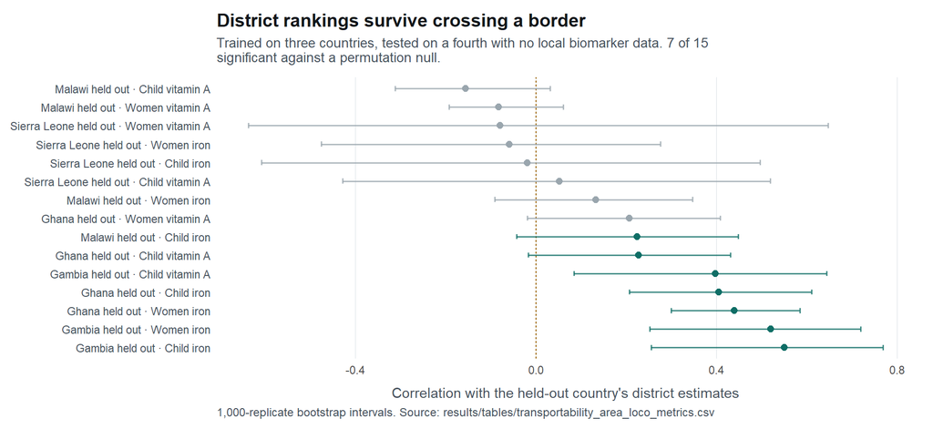

## Which is why anchoring to regional totals is the design that pays

The model supplies the ranking; the design-based survey supplies the level.

| Approach | Cells | Mean r | MAE (pp) | Mean \|bias\| (pp) |
| --- | --- | --- | --- | --- |
| District model anchored to regional totals | 24 | 0.413 | 8.85 | 1.59 |
| District model, shrunken regional anchor | 24 | 0.318 | 9.36 | 2.76 |
| Fit at region, extrapolated to district | 22 | 0.230 | 8.78 | 3.18 |
| District model anchored to national total | 24 | 0.170 | 11.98 | 5.85 |
| District model alone, no anchor | 24 | 0.164 | 10.71 | 3.24 |

Anchoring to *regions* more than doubles rank correlation (0.164 → 0.413) and cuts bias from 3.24 to 1.59 pp — better in 20 of 24 cells. Anchoring to one *national* total adds nothing (+0.006) and makes bias worse: it moves every district by the same amount, including the ones already right.

## Could a predicted national level stand in where there is no survey?

No — and the oracle arm shows it never could.

| Arm | MAE (pp) | Mean \|bias\| (pp) | Better |
| --- | --- | --- | --- |
| Transported, no level | 5.81 | 3.35 | — |
| + national null level | 8.22 | 4.69 | 1/8 |
| + VMNIS predicted level | 12.70 | 10.03 | 1/8 |
| + **true** national level (oracle) | 5.58 | 0.73 | 4/8 |

The VMNIS model is good at ranking countries (r = 0.655 against a 0.818 ceiling, 80%). But its *levels* sit on a different scale — 40.9 pp predicted for Sierra Leone against a true 12.2 — and **even a perfect national level buys 0.23 pp**. No amount of national modelling can raise that.

## Would an actual household survey do better? Barely

Same rows, same folds, proxies swapped for the questionnaire administered to these very people — wealth, education, diet, WASH, illness, supplementation, ~330 columns — with every blood-assay column removed.

| Unit | Predictors | Mean r | Median r | MAE (pp) |
| --- | --- | --- | --- | --- |
| District | geospatial proxies | 0.154 | 0.126 | 8.33 |
| District | **household questionnaire** | 0.228 | 0.264 | 7.92 |
| Cluster | geospatial proxies | 0.146 | 0.126 | 12.79 |
| Cluster | household questionnaire | 0.229 | 0.212 | 9.27 |

Clears r = 0.4 in 3 of 16 cells; adds nothing at all in Malawi.

**This is what rules out the easy explanations**

Not bad linkage, not the inflammation adjustment, not overfitting — a questionnaire with no geospatial data in it also cannot say which *district* a deficiency is in. The signal is weak at this resolution for everyone.

## National prevalence is where the models genuinely work

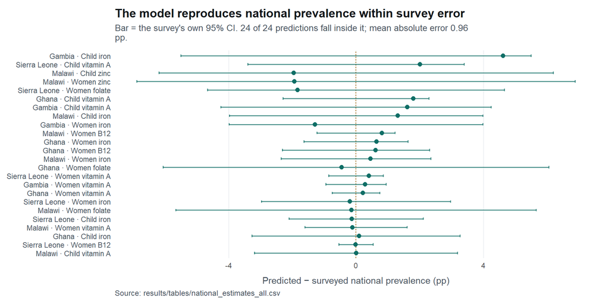

All 24 predictions fall inside the survey’s own 95% CI; mean absolute error 0.96 pp.

## Data we hold and do not use

| Opportunity | Where | Size |
| --- | --- | --- |
| **sTfR** — body iron stores, less inflammation-sensitive | **all four countries** | full biomarker sample |
| School-age children (5–14 y), `vitA_def` + `iron_def` already derived | Malawi | 758 |
| Men | Malawi | 219 |
| Urinary iodine | Gambia, Sierra Leone | 1,383 / 1,422 |
| RBC folate (long-term status) | Malawi | 797 |

sTfR is the most promising: the cross-country failure lives in raw ferritin, so an iron outcome that leans less on ferritin attacks the problem directly.

## One inconsistency worth fixing before publication

**Vitamin A is BRINDA-harmonised across all four countries. Iron is not.**

| Country | iron adjustment used |
| --- | --- |
| The Gambia | `gw_LogFerAdj` (log scale) |
| Ghana | `gw_cFerrAdjThurn` (Thurnham) |
| Sierra Leone | `gw_wFerAdjBR1` (BRINDA regression) |
| Malawi | `sf_reg` (regression-adjusted) |

The raw ingredients for a uniform BRINDA adjustment (marker, CRP, AGP) exist in all four. Harmonising it does **not** fix transport — that was tested, and the offset is in raw ferritin — but harmonising one outcome and not the other is hard to defend in review.

## Where this leaves the programme

**Defensible now**

- National prevalence, within survey error, in every cell
- District *rankings*, anchored to design-based regional totals
- Targeting value: above 1.0x lift in 22 of 24 combinations

**Not defensible**

- Absolute district prevalence from covariates alone
- Any accuracy figure whose covariates were screened on all the data

**Most promising next**

- sTfR-based iron outcomes across all four countries
- Continuous biomarkers rather than binaries, especially for rare outcomes
- Malawi’s school-age children as a fifth population

## Variable importance: what the ablations actually say

Two headline numbers from the domain ablation are **artifacts**, and finding that is the result.

| Domain removed | mean AUC lost |
| --- | --- |
| Survey Indicators | 0.152 |
| Infant & Child Mortality | 0.121 |
| HIV/AIDS | 0.117 |
| Agriculture | 0.114 |

Removing **one** HIV/AIDS variable cannot cost 0.12 AUC. It doesn’t.

## Two degenerate cells were driving every domain

Both are rare outcomes. Removing even one predictor destabilises the fit entirely — the same rare-outcome fragility that shows up in the Admin-1 comparison.

## Excluding those two cells, domain removal costs nothing

| Domain removed | variables | **median** AUC lost |
| --- | --- | --- |
| Environment | 57 | **0.029** |
| Climate | 21 | 0.004 |
| Survey Indicators | 3 | 0.001 |
| Infectious Disease | 12 | 0.001 |
| Infrastructure | 2 | 0.001 |
| Water & Sanitation | 10 | 0.001 |

- **141 of 332** domain removals *improve* AUC
- **266 of 720** single-variable permutation drops are $\le 0$
- Median top-5 permutation drop: **0.008 AUC**

Only Environment — 57 variables — has a median cost distinguishable from zero.

## No variable is consistently important

Across 24 country x outcome cells, the variable ranked **first** by permutation importance is:

| Top-ranked variable | cells (of 24) |
| --- | --- |
| `dhs2014_AN_ANEM_W_ANY` | 3 |
| `dhs2015_CH_VACC_C_DP1_adm2` | 2 |
| every other variable | 1 |

SHAP tells the same story: the top-ranked contributions are `mean_abs_shap` ~ 0.004 on the probability scale — a 0.4 percentage-point influence per district.

## So: is anything associated with the outcomes at all?

Bivariate association between every harmonised predictor and district prevalence, ~296 predictors x 24 cells, with two nulls:

- **Naive** correlation test — treats districts as independent
- **Restricted permutation** — shuffles the outcome *within* Admin-1 regions, holding the regional pattern fixed, so a covariate must explain district-level deviation on top of geography

The gap between the two is the spatial-confounding correction. Malawi women’s B12: **48** predictors significant naively, **15** under the restricted null.

*(Full FDR results and the penalised-regression retained sets follow.)*

## Nothing survives FDR once space is accounted for

7,104 tests: ~296 harmonised predictors x 24 country x outcome cells.

| Test | significant | of 7,104 |
| --- | --- | --- |
| Naive $p < 0.05$ | 1,209 | 17.0% |
| Naive, BH within cell | 476 | 6.7% |
| Naive, BH across all cells | 310 | 4.4% |
| **Restricted permutation $p < 0.05$** | **519** | **7.3%** |
| **Restricted, BH within cell** | **0** | **0.00%** |
| **Restricted, BH across all cells** | **0** | **0.00%** |

Expected by chance at $p<0.05$: **355**.

Naive testing gives 3.4x enrichment over chance. The spatially-restricted null gives **1.5x** — and after FDR correction, **not one predictor survives, in any cell**.

## What that does and does not mean

The restricted permutation holds the **regional** pattern fixed and asks what a covariate adds *on top of geography*. It is deliberately conservative, and it is not the same target as the LORO models, which predict held-out **regions**.

Read together:

- **Between-region** association exists — 310 predictors survive global BH on the naive test — but is confounded with spatial smoothness
- **Within-region**, beyond what geography already gives you: **nothing**

Which is exactly why a covariate-free spatial smoother matches 294 covariates. Two results, one explanation.

The strongest single associations are mechanistically sensible and still fail multiplicity: Gambia women’s iron vs women’s secondary education $r = -0.76$ ($p_{perm} = 0.002$, $q = 0.20$); Gambia women’s vitamin A vs 2019 precipitation $r = -0.64$.

## Penalised regression agrees: mostly nothing is retained

Elastic net ($\alpha = 0.5$), CV-selected $\lambda_{1se}$, per cell:

| Median predictors retained | **0** |
| --- | --- |
| Cells retaining **nothing** | **13 of 18** |
| Mean deviance explained | 0.063 |

| Country | outcomes with $>0$ retained |
| --- | --- |
| Gambia | child iron (3), women iron (9) |
| Ghana | child vitA (3), child iron (16), women iron (15) |
| **Malawi** | **none — 0 of 8, on 87 districts** |

At the looser $\lambda_{min}$ the median rises to 8.5 predictors and deviance explained to 0.255 — but that is the penalty CV rejects.

## The signal, where it exists, is iron

Every cell retaining predictors under $\lambda_{1se}$ is an **iron** outcome, bar one. Vitamin A, folate, B12 and zinc retain nothing anywhere.

Malawi retaining zero predictors across all eight outcomes on 87 districts is the single most informative number here. It is not a power problem.

## Model the biomarker, or the binary?

Every outcome here is a prevalence: the share below a cutoff. Dichotomising discards information, most of it when the outcome is rare. We tested modelling the district **mean of the log biomarker** and converting afterwards.

22 cells, leave-one-region-out, same covariates and stack:

| Arm | MAE (pp) | RMSE (pp) | rank $r$ |
| --- | --- | --- | --- |
| 1 binary (direct) | 9.40 | 12.36 | 0.168 |
| 2 continuous $\rightarrow$ prevalence | 10.80 | 13.08 | 0.196 |
| 3 continuous, oracle SD | 9.92 | 12.20 | 0.434 |
| **4 conversion ceiling (true mean)** | **7.49** | **9.11** | **0.672** |
| 5 null (train mean) | 8.06 | 10.14 | — |

## The conversion is not the problem. Predicting the mean is.

Arm 4 feeds the **true** district mean through the same conversion — no prediction at all. It reaches MAE 7.49 and $r$ = 0.672, beating every other arm **including the null**, and beats the binary arm in 14 of 22 cells.

So the mean-to-prevalence step is sound. A district mean predicted well would convert to prevalence better than anything we currently produce. The entire deficit is in predicting the mean — which fails for the same reason everything else does.

District-mean prediction on the continuous scale, $r$ ranges **–0.68 to +0.69**. In 9 of 22 cells the RMSE of the predicted mean *exceeds* the between-district SD — worse than predicting the overall mean.

## Rarity: the hypothesis holds, with one caveat

| Prevalence band | cells | binary MAE | continuous MAE |
| --- | --- | --- | --- |
| **rare (<5%)** | 6 | 4.61 | **2.99** |
| mid (5–20%) | 10 | 8.77 | 11.86 |
| common (>20%) | 6 | 15.25 | 16.84 |

Continuous cuts error by 35% where the outcome is rare, and is worse elsewhere.

**One cell dominates that average.** Sierra Leone women’s B12 (0.61% prevalence): binary MAE **7.67 pp** — a nonsensical error on a 0.6% outcome — against **0.53** for continuous. Excluding it, continuous wins 3 of the remaining 5 rare cells by modest margins.

Neither arm reliably beats the null: binary in 4 of 22 cells, continuous in 2.

## What the continuous route is and is not worth

**Worth doing**

- For **rare outcomes**, where the binary model can produce absurd errors
- Because the conversion ceiling shows real headroom ($r$ = 0.672)
- Because the oracle-SD arm ($r$ = 0.434 vs 0.196) shows the within-district spread carries information a single pooled SD discards

**Not a fix**

- It does not rescue ranking: 0.196 vs 0.168 overall
- It is *worse* on absolute error for mid and common outcomes
- It leaves the binding constraint untouched — the district mean is no easier to predict from these covariates than the prevalence is

## WHO risk categories: the policy-legible version

Classifying each district into the WHO public-health categories (None / Mild / Moderate / Severe) for child vitamin A:

| Level | units | covariates exact | **null exact** | covariates within-1 | null within-1 |
| --- | --- | --- | --- | --- | --- |
| **Admin-2** | 206 | 33% | **32%** | 69% | 63% |
| **Admin-1** | 43 | **56%** | 35% | 95% | 91% |

At Admin-2 the covariate model classifies risk categories **no better than assigning every district the national prevalence** — 33% against 32%. At Admin-1 the gap is real: 56% against 35%.

The 2026 Ghana deck reported 56% exact at Admin-1, which reproduces exactly. Its Admin-2 figures (44% full model / 31% proxies-only) are consistent with the 31–33% seen here for a proxy-only model.

## Resolution result, confirmed on the rebuilt covariates

Re-run against the restored `area_covariates_*` targets — identical to the first pass, so the numbers are not an artifact of the fallback path:

|  | covariates | spatial only | beats spatial |
| --- | --- | --- | --- |
| **Admin-2** (24 cells) | $r$ = 0.156 | $r$ = 0.137 | 6 / 24 |
| **Admin-1** (14 cells) | $r$ = **0.437** | $r$ = 0.209 | 7 / 14 |
| **Hybrid** (24 cells) | $r$ = **0.304**, MAE 7.25 pp | $r$ = 0.140, MAE 7.30 pp | 10 / 24 |

Gambia (6 regions) and Sierra Leone (4) are **not estimable** at Admin-1 and fall back to Admin-2 under the a-priori rule.

## What should the model carry across a border?

District ranking transports; the absolute level does not. So stop asking the model to carry the level. Two versions of that idea, opposite answers:

| target | Spearman | MAE (pp) | \|bias\| (pp) |
| --- | --- | --- | --- |
| level (baseline) | 0.146 | 13.8 | 10.2 |
| deviation from national mean | *worse* | — | — |
| **within-country z-score** | **0.199** | **10.0** | **5.9** |

Removing the country **mean** alone fails — it leaves the between-country **spread** in the target. Removing both is what works: +0.053 Spearman, better in 3 of 4 outcomes.

**Do not quote the two gains together.** A positive rescale plus an offset cannot reorder predictions, so the rank gain is a real modelling improvement. The larger error and bias gains come mostly from the **anchor** — the held-out country’s national prevalence — which is a deployment assumption, not evidence the covariates improved.

## Two changes that did not replicate

Reported because the negative result is the useful part.

| change | expected | measured | better in |
| --- | --- | --- | --- |
| raw prevalence scale (drop the logit clamp) | +0.048 | **–0.020** | 2 / 4 |
| district coordinates as predictors | +0.063 | **0.000** | 1 / 4 |
| link at the survey cluster, not the district | largest where clusters most outnumber districts | **–0.025** in exactly that country | 3 / 8 |

The raw-scale result had a strong prior: **8 of 24 cells have >40% of districts observed at exactly 0%**, every one clamped to logit = –5.3. It still did not help this recipe. The earlier gain was largest for a *spatial spline*, which is a different model.

Coordinates fail for a mechanical reason: with a top-30 correlation prescreen over 294 predictors, two coordinate columns rarely survive selection. The earlier gain came from a curated 16-variable set where coordinates were a large share of the model.

Cluster linkage was predicted to pay most in **Sierra Leone** (58 clusters vs 14 districts). It is the country where it does *worst*. More units to fit does not help when each unit’s outcome rests on a handful of people — the units get noisier in the same proportion as they get more numerous.

Both are kept in the code as options — and the scale dispatcher fixed a real defect, since `recipe$scale` previously did nothing at all.